# Análise das Commodities

Soja | Milho | Café | Boi Gordo  
Professor: Sinézio Maia

Author

Maria Carolina

Published

March 27, 2026

# 1 · Visão Geral dos Dados

Primeiras observações por commodity (colunas recalculadas)

| Commodity | Data | SPOT | FUT Invest | Base | Res. Venda | R$ Venda | Res. Compra | R$ Compra |
| --- | --- | --- | --- | --- | --- | --- | --- | --- |
| Soja | 2025-03-05 | 133.44 | 129.16 | 4.28 | NA | NA | NA | NA |
|  | 2025-03-06 | 135.72 | 130.18 | 5.54 | -1.02 | -459.0 | 1.02 | 459.0 |
|  | 2025-03-07 | 134.19 | 130.34 | 3.85 | -0.16 | -72.0 | 0.16 | 72.0 |
|  | 2025-03-10 | 134.86 | 129.49 | 5.37 | 0.85 | 382.5 | -0.85 | -382.5 |
|  | 2025-03-11 | 134.52 | 130.06 | 4.46 | -0.57 | -256.5 | 0.57 | 256.5 |
| Milho | 2025-03-05 | 87.67 | 86.41 | 1.26 | NA | NA | NA | NA |
|  | 2025-03-06 | 87.85 | 86.64 | 1.21 | -0.23 | -103.5 | 0.23 | 103.5 |
|  | 2025-03-07 | 88.71 | 86.10 | 2.61 | 0.54 | 243.0 | -0.54 | -243.0 |
|  | 2025-03-10 | 88.52 | 87.85 | 0.67 | -1.75 | -787.5 | 1.75 | 787.5 |
|  | 2025-03-11 | 89.08 | 87.46 | 1.62 | 0.39 | 175.5 | -0.39 | -175.5 |
| Café | 2025-03-05 | 2612.63 | 2950.12 | -337.49 | NA | NA | NA | NA |
|  | 2025-03-06 | 2543.07 | 2757.46 | -214.39 | 192.66 | 86697.0 | -192.66 | -86697.0 |
|  | 2025-03-07 | 2514.82 | 2745.66 | -230.84 | 11.80 | 5310.0 | -11.80 | -5310.0 |
|  | 2025-03-10 | 2525.06 | 2750.81 | -225.75 | -5.15 | -2317.5 | 5.15 | 2317.5 |
|  | 2025-03-11 | 2561.17 | 2848.50 | -287.33 | -97.69 | -43960.5 | 97.69 | 43960.5 |
| Boi Gordo | 2025-03-05 | 309.70 | 298.20 | 11.50 | NA | NA | NA | NA |
|  | 2025-03-06 | 311.00 | 301.05 | 9.95 | -2.85 | -1282.5 | 2.85 | 1282.5 |
|  | 2025-03-07 | 311.65 | 302.30 | 9.35 | -1.25 | -562.5 | 1.25 | 562.5 |
|  | 2025-03-10 | 311.45 | 307.15 | 4.30 | -4.85 | -2182.5 | 4.85 | 2182.5 |
|  | 2025-03-11 | 311.95 | 305.10 | 6.85 | 2.05 | 922.5 | -2.05 | -922.5 |

# 2 · SPOT vs FUT Invest

> Comparação entre o preço à vista (CEPEA) e o preço futuro (Investing.com) para cada commodity.

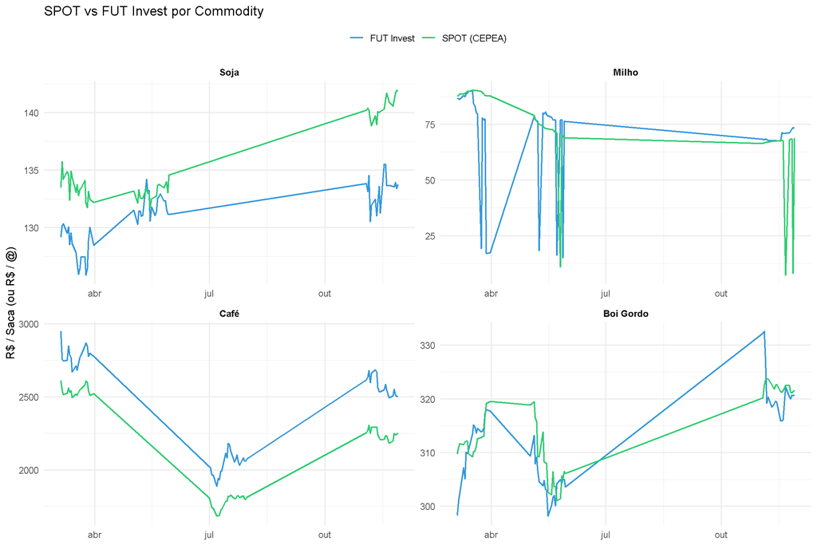

# 3 · Risco de Base

> **Base = SPOT − FUT Invest**.  
> Base positiva → físico valorizado sobre o futuro .  
> Base negativa → futuro acima do físico .

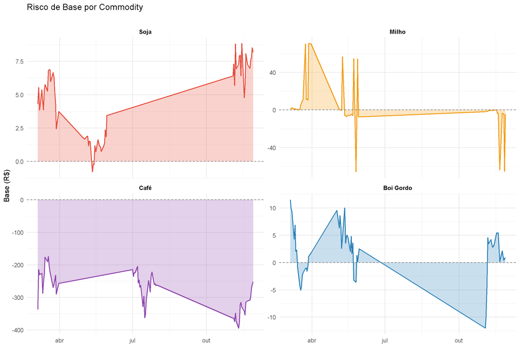

# 4 · Estatísticas do Risco de Base

Estatísticas descritivas da Base por commodity

| Commodity | N | Média | Desvio P. | CV (%) | Mínimo | Máximo | Amplitude | Base > 0 |
| --- | --- | --- | --- | --- | --- | --- | --- | --- |
| Soja | 59 | 4.468 | 2.766 | 61.904 | -0.78 | 8.83 | 9.61 | 94.9% |
| Milho | 58 | 2.651 | 25.703 | 969.488 | -65.94 | 70.84 | 136.78 | 43.1% |
| Café | 61 | -276.863 | 55.375 | 20.001 | -394.10 | -174.07 | 220.03 | 0% |
| Boi Gordo | 59 | 2.076 | 4.562 | 219.768 | -12.00 | 11.50 | 23.50 | 74.6% |

# 5 · Resultados do Hedge

## 5.1 · Resultado Diário (R$/contrato de 450 sacas)

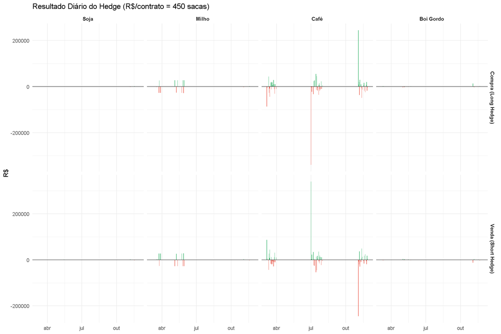

## 5.2 · Resultado Acumulado

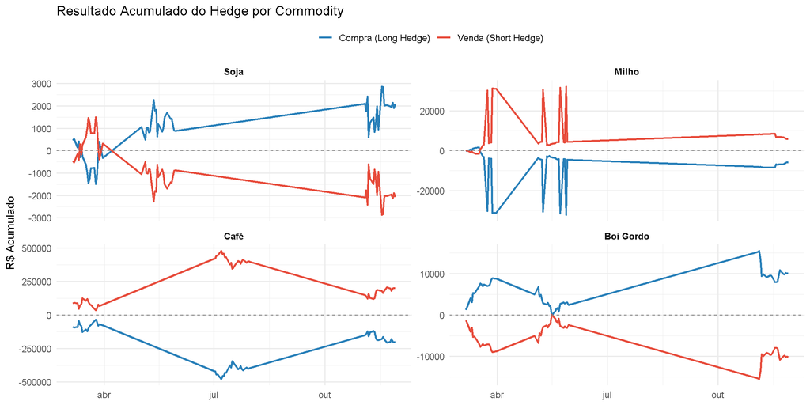

## 5.3 · Tabela de Resultados Totais

Resultado total do hedge por commodity (1 contrato = 450 sacas)

| Commodity | Dias | Base Média | Base SD | Res. Venda (Σ R$) | Dias + Venda | Dias - Venda | Res. Compra (Σ R$) | Dias + Compra | Dias - Compra |
| --- | --- | --- | --- | --- | --- | --- | --- | --- | --- |
| Soja | 58 | 4.47 | 2.79 | -2070.0 | 26 | 32 | 2070.0 | 32 | 26 |
| Milho | 57 | 2.68 | 25.93 | 5935.5 | 32 | 25 | -5935.5 | 25 | 32 |
| Café | 60 | -275.85 | 55.27 | 200182.5 | 30 | 30 | -200182.5 | 30 | 30 |
| Boi Gordo | 58 | 1.91 | 4.43 | -10120.5 | 25 | 31 | 10120.5 | 31 | 25 |

# 6 · Distribuição da Base (Histogramas)

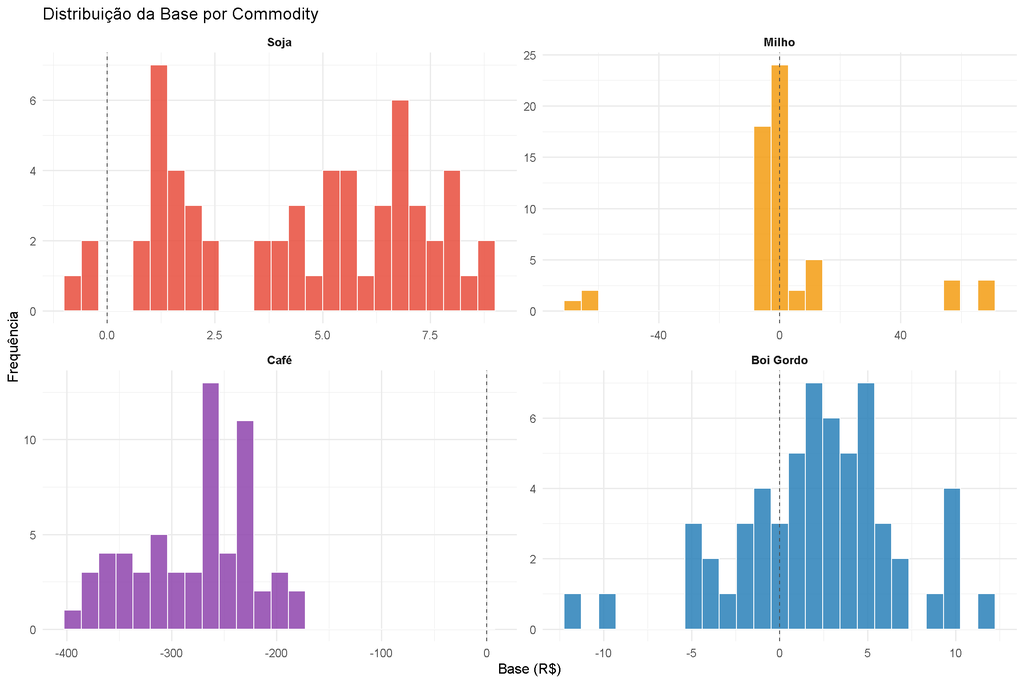

# 7 · Glossário das Colunas Calculadas

Definição e fórmula de cada coluna calculada

[output not shown]

# Explicação:

### 1. Milho (Contratos CCM)

**Meses escolhidos:** Março, Maio e Novembro de 2025.

**Por que escolhi esses meses?** A época de safra (quando tem muito milho) acontece entre fevereiro e maio. A entressafra (quando o milho fica escasso) vai de setembro a dezembro. Escolhi Março e Maio para analisar o período de fartura, e Novembro para ver como o preço se comporta na época de escassez.

**Estratégia: Compra ou Venda?**

- **Cenário:** A previsão é de **queda nos preços**. A produção vai crescer, os estoques vão mais que dobrar e as exportações devem cair um pouco. Ou seja, vai sobrar milho no mercado.
- **Para o Produtor (Agricultor): Fazer Hedge de Venda.** Como o preço vai cair, ele precisa “travar” um preço de venda no mercado futuro agora. Assim, ele garante o lucro e não toma prejuízo quando for vender a colheita física mais barata.
- **Para o Processador (Fábricas/Granjas): Fazer Hedge de Compra.** O cenário é ótimo, pois ele vai comprar milho mais barato. Mas, para evitar surpresas (como uma seca de última hora que faça o preço subir), ele pode comprar um “seguro” no mercado futuro, estabelecendo um preço máximo para o seu custo.

### 2. Soja (Contratos SJC)

**Meses escolhidos:** Março, Maio e Novembro de 2025.

**Por que escolhi esses meses?** A lógica é a mesma do milho. Março e Maio representam o auge da colheita (muita soja no mercado e preço pressionado). Novembro representa a entressafra (pouca soja disponível, antes da nova colheita).

**Estratégia: Compra ou Venda?**

- **Cenário:** A previsão também é de **queda nos preços**. Teremos uma safra recorde e os estoques vão dobrar. Mesmo com os problemas de seca no Rio Grande do Sul, ainda vai sobrar muita soja.
- **Para o Produtor (Agricultor): Fazer Hedge de Venda.** A pressão para os preços caírem é enorme. O agricultor precisa fechar contratos de venda no mercado futuro o quanto antes para garantir um preço bom antes que o valor despenque no mercado físico.
- **Para o Processador (Indústrias/Frigoríficos): Fazer Hedge de Compra (como precaução).** Para quem compra soja, o momento é excelente. O hedge de compra aqui serve apenas como uma garantia de segurança no orçamento da empresa, protegendo contra aumentos rápidos causados, por exemplo, por uma alta do dólar.

### 3. Boi Gordo (Contratos BGI)

**Meses escolhidos:** Maio, Outubro e Novembro de 2025.

**Por que escolhi esses meses?** O mercado de gado depende muito das chuvas. Em Maio, o pasto seca e muito gado é mandado para o abate (safra do boi). Já Outubro e Novembro são meses de entressafra, em que o mercado depende dos bois criados em confinamento e se prepara para as vendas de fim de ano.

### 4. Café Arábica (Contratos ICF)

**Por que escolhi esses meses?** A colheita do café acontece entre julho e setembro. O pico de escassez é em março (estoques baixos). Escolhi Março para analisar a falta de café, e Julho e Setembro para analisar o mercado durante o andamento e o fim da colheita.

**Estratégia: Compra ou Venda?**

- **Cenário:** A previsão é de **queda nos preços**. A safra vai ser maior do que o esperado e a produção de café conilon disparou. Com muito café disponível no mercado, o preço cai.
- **Para o Produtor (Cafeicultor): Fazer Hedge de Venda.** Como a tendência é de baixa, o produtor precisa “travar” o preço no mercado futuro. Se o preço da saca no mercado físico desabar até a colheita, ele compensa essa perda ganhando dinheiro na operação financeira.
- **Para o Processador (Torrefações): Fazer Hedge de Compra (como seguro).** A indústria sai ganhando pagando menos pelo café. Porém, como o clima no café é muito instável (risco de geadas repentinas), vale a pena travar um teto de preço no mercado futuro para não ser pego de surpresa.

*Gerado automaticamente com R + Quarto. Fontes: CEPEA (SPOT), Investing.com (FUT Invest), IPEA (câmbio).*